# Adani transmission stock

### **Author:** [Arun Kumar Pandey](https://arunp77.github.io/)

**Example: -1** Portfolio Risk for my investment in Adani Transmission share price

```python
# installing yfinance
%pip install yfinance -q
```

```python
# importing important libraries
import pandas as pd
import numpy as np
import yfinance as yf
import matplotlib.pyplot as plt
import seaborn as sns
```

```python
# Get historical price data for Adani Transmission

ticker = 'ADANITRANS.NS'  # Ticker symbol for Adani Transmission
start_date = '2022-01-01'  # Start date for the historical data
end_date = '2023-04-30'  # End date for the historical data

adani_df0 = yf.download(ticker, start=start_date, end=end_date)
adani_df0.head()
```

```
[*********************100%***********************]  1 of 1 completed
```

| Date | Open | High | Low | Close | Adj Close | Volume |
| --- | --- | --- | --- | --- | --- | --- |
| 2022-01-03 | 1735.000000 | 1755.0 | 1710.000000 | 1731.099976 | 1731.099976 | 32602 |
| 2022-01-04 | 1731.099976 | 1775.0 | 1700.000000 | 1754.949951 | 1754.949951 | 42498 |
| 2022-01-05 | 1706.099976 | 1780.5 | 1706.099976 | 1761.050049 | 1761.050049 | 54105 |
| 2022-01-06 | 1730.000000 | 1770.0 | 1710.000000 | 1760.050049 | 1760.050049 | 51023 |
| 2022-01-07 | 1740.099976 | 1780.0 | 1721.849976 | 1776.000000 | 1776.000000 | 64894 |

```python
adani_df0.dtypes
```

```
Open         float64
High         float64
Low          float64
Close        float64
Adj Close    float64
Volume         int64
dtype: object
```

```python
adani_df0.columns
```

```
Index(['Open', 'High', 'Low', 'Close', 'Adj Close', 'Volume'], dtype='object')
```

```python
# checking missing values i.e. NaN values
adani_df0.isnull().sum()
```

```
Open         0
High         0
Low          0
Close        0
Adj Close    0
Volume       0
dtype: int64
```

```python
# shape of the dataframe
adani_df0.shape
```

```
(327, 6)
```

```python
#basic statistics
adani_df0.describe()
```

|  | Open | High | Low | Close | Adj Close | Volume |
| --- | --- | --- | --- | --- | --- | --- |
| count | 327.000000 | 327.000000 | 327.000000 | 327.000000 | 327.000000 | 3.270000e+02 |
| mean | 2402.030275 | 2456.439752 | 2339.146184 | 2397.370334 | 2397.370334 | 6.421608e+05 |
| std | 858.588234 | 873.262823 | 837.562902 | 854.741647 | 854.741647 | 7.021228e+05 |
| min | 631.500000 | 674.400024 | 631.500000 | 642.900024 | 642.900024 | 3.088600e+04 |
| 25% | 1992.500000 | 2039.500000 | 1934.575012 | 1989.674988 | 1989.674988 | 2.684495e+05 |
| 50% | 2468.000000 | 2515.000000 | 2401.949951 | 2453.500000 | 2453.500000 | 4.412000e+05 |
| 75% | 2991.775024 | 3022.000000 | 2944.349976 | 2987.125000 | 2987.125000 | 7.467140e+05 |
| max | 4165.000000 | 4236.750000 | 3991.100098 | 4105.399902 | 4105.399902 | 5.208061e+06 |

```python
adani_df0.max()
```

```
Open         4.165000e+03
High         4.236750e+03
Low          3.991100e+03
Close        4.105400e+03
Adj Close    4.105400e+03
Volume       5.208061e+06
dtype: float64
```

```python
adani_df0.min()
```

```
Open           631.500000
High           674.400024
Low            631.500000
Close          642.900024
Adj Close      642.900024
Volume       30886.000000
dtype: float64
```

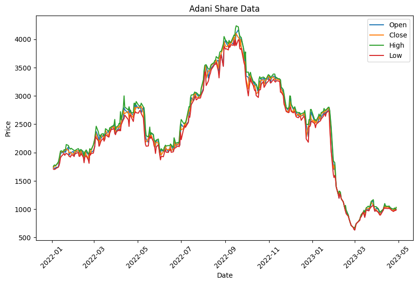

```python
# If date is not datetime format then Convert the 'Date' column to datetime type using
# adani_df['Date'] = pd.to_datetime(adani_df['Date'])

# Set the figure size
plt.figure(figsize=(10, 6))
# Plot 'Open' price
sns.lineplot(x='Date', y='Open', data=adani_df0, label='Open')

# Plot 'Close' price
sns.lineplot(x='Date', y='Close', data=adani_df0, label='Close')

# Plot 'High' price
sns.lineplot(x='Date', y='High', data=adani_df0, label='High')

# Plot 'Low' price
sns.lineplot(x='Date', y='Low', data=adani_df0, label='Low')

# Set the labels and title
plt.xlabel('Date')
plt.ylabel('Price')
plt.title('Adani Share Data')

# Rotate x-axis labels for better readability
plt.xticks(rotation=45)

# Display the legend
plt.legend()

# Show the plot
plt.show()
```

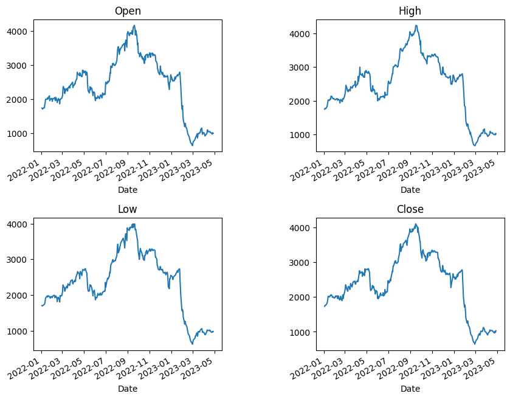

```python
# we can also plot all four in separate subfigures in a single figure

# For duration 1996-2023
fig, ax = plt.subplots(2, 2, figsize=(10, 8))
adani_df0['Open'].plot(ax=ax[0,0], title= 'Open') # type: ignore
adani_df0['High'].plot(ax=ax[0,1], title= 'High') # type: ignore
adani_df0['Low'].plot(ax=ax[1,0], title= 'Low') # type: ignore
adani_df0['Close'].plot(ax=ax[1,1], title= 'Close') # type: ignore
# Adjust spacing between subplots
fig.subplots_adjust(wspace=0.5, hspace=0.5)
```

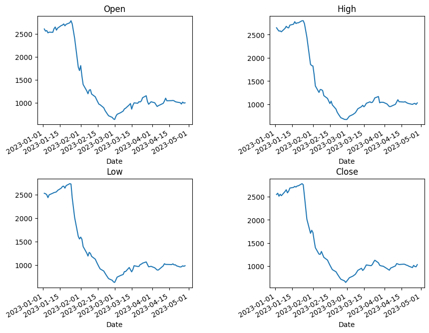

```python
# we can also plot all four in separate subfigures in a single figure

# For duration 1996-2023
fig, ax = plt.subplots(2, 2, figsize=(10, 8))
adani_df0['Open'].loc['2023-01-01':'2023-06-01'].plot(ax=ax[0,0], title= 'Open') # type: ignore
adani_df0['High'].loc['2023-01-01':'2023-06-01'].plot(ax=ax[0,1], title= 'High') # type: ignore
adani_df0['Low'].loc['2023-01-01':'2023-06-01'].plot(ax=ax[1,0], title= 'Low') # type: ignore
adani_df0['Close'].loc['2023-01-01':'2023-06-01'].plot(ax=ax[1,1], title= 'Close') # type: ignore
# Adjust spacing between subplots
fig.subplots_adjust(wspace=0.5, hspace=0.5)
```

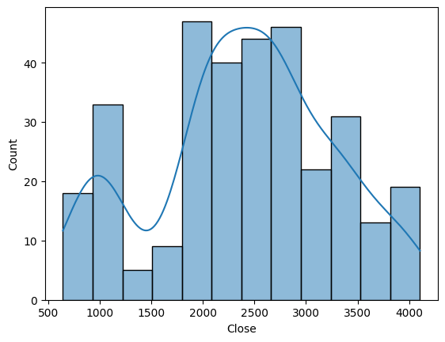

```python
# Plot histogram
sns.histplot(data = adani_df0['Close'], kde = True)
plt.show()
```

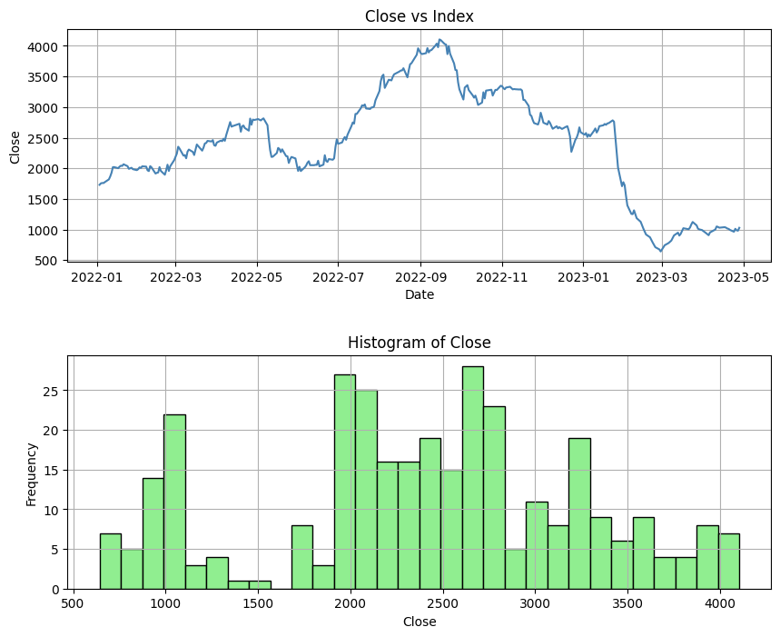

```python
# Create subplots with 2 rows and 1 column
fig, axs = plt.subplots(2, 1, figsize=(10, 8))

# Plot 'Close' vs index
axs[0].plot(adani_df0.index, adani_df['Close'], color='steelblue')
axs[0].set_xlabel('Date')
axs[0].set_ylabel('Close')
axs[0].set_title('Close vs Index')
axs[0].grid(True)

# Plot histogram for 'Close'
axs[1].hist(adani_df0['Close'], bins=30, color='lightgreen', edgecolor='black')
axs[1].set_xlabel('Close')
axs[1].set_ylabel('Frequency')
axs[1].set_title('Histogram of Close')
axs[1].grid(True)

# Adjust spacing between subplots
plt.subplots_adjust(hspace=0.4)

# Show the plot
plt.show()
```

## 1. Daily changes & % changes

Here in this section, we will do our calculation in a copied dataframe, so that our original dataframe remain intact while doing these calculations for our future references.

- Daily change $\Rightarrow $ Daily Change = Current Value - Previous Value
  - 'Current Value' represents the value of a data point at a specific time (e.g., the closing price of a stock on a particular day).
  - 'Previous Value' represents the value of the same data point at the previous time (e.g., the closing price of the stock on the previous day).

```python
# copying original dataframe

adani_df = adani_df0.copy()
adani_df.head()
```

| Date | Open | High | Low | Close | Adj Close | Volume |
| --- | --- | --- | --- | --- | --- | --- |
| 2022-01-03 | 1735.000000 | 1755.0 | 1710.000000 | 1731.099976 | 1731.099976 | 32602 |
| 2022-01-04 | 1731.099976 | 1775.0 | 1700.000000 | 1754.949951 | 1754.949951 | 42498 |
| 2022-01-05 | 1706.099976 | 1780.5 | 1706.099976 | 1761.050049 | 1761.050049 | 54105 |
| 2022-01-06 | 1730.000000 | 1770.0 | 1710.000000 | 1760.050049 | 1760.050049 | 51023 |
| 2022-01-07 | 1740.099976 | 1780.0 | 1721.849976 | 1776.000000 | 1776.000000 | 64894 |

```python
# daily change = Open price - Closing price
# Calculate daily change
adani_df['Daily Change'] = adani_df['Close'].diff()

# Calculate percentage daily change
adani_df['% Daily Change'] = adani_df['Close'].pct_change() * 100

adani_df.head()
```

| Date | Open | High | Low | Close | Adj Close | Volume | Daily Change | % Daily Change |
| --- | --- | --- | --- | --- | --- | --- | --- | --- |
| 2022-01-03 | 1735.000000 | 1755.0 | 1710.000000 | 1731.099976 | 1731.099976 | 32602 | NaN | NaN |
| 2022-01-04 | 1731.099976 | 1775.0 | 1700.000000 | 1754.949951 | 1754.949951 | 42498 | 23.849976 | 1.377735 |
| 2022-01-05 | 1706.099976 | 1780.5 | 1706.099976 | 1761.050049 | 1761.050049 | 54105 | 6.100098 | 0.347594 |
| 2022-01-06 | 1730.000000 | 1770.0 | 1710.000000 | 1760.050049 | 1760.050049 | 51023 | -1.000000 | -0.056784 |
| 2022-01-07 | 1740.099976 | 1780.0 | 1721.849976 | 1776.000000 | 1776.000000 | 64894 | 15.949951 | 0.906221 |

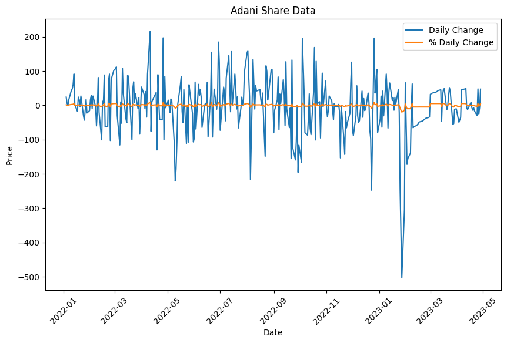

```python
# If date is not datetime format then Convert the 'Date' column to datetime type using
# adani_df['Date'] = pd.to_datetime(adani_df['Date'])

# Set the figure size
plt.figure(figsize=(10, 6))

sns.lineplot(x='Date', y='Daily Change', data=adani_df, label='Daily Change')
sns.lineplot(x='Date', y='% Daily Change', data=adani_df, label='% Daily Change')

# Set the labels and title
plt.xlabel('Date')
plt.ylabel('Price')
plt.title('Adani Share Data')

# Rotate x-axis labels for better readability
plt.xticks(rotation=45)

# Display the legend
plt.legend()

# Show the plot
plt.show()
```

## 2. Retrun

Returns, in the context of finance and investing, refer to the financial gain or loss on an investment or asset over a specific period. - It measures the percentage change in the value of the investment relative to the initial investment or the previous value.

- Returns are commonly used to evaluate the performance of investments, compare investment options, and assess the profitability of trading strategies.
  - returns > 0 $\Rrightarrow$ profit or gain
  - returns < 0 $\Rrightarrow$ loss.
- There are various types of returns depending on the specific calculation and time period considered. Some common types of returns include:
  1. **Total Return:** It measures the overall return on an investment, taking into account both price appreciation (capital gains) and any income generated (such as dividends or interest).

     $\boxed{{\rm Total ~Return} = \frac{{\rm Ending ~ Value} - {\rm Beginning ~ Value} + {\rm Income}}{{\rm Beginning ~ Value}}}$

     where:
     - `Ending Value` is the value of the investment at the end of the period.
     - `Beginning Value` is the value of the investment at the beginning of the period.
     - `Income` refers to any additional income generated during the period, such as dividends or interest.
  2. **Price Return:** Also known as capital gain or price appreciation, it represents the percentage change in the price or value of an investment over a specified time period.

     $\boxed{\text{Price Return} = \frac{\text{Ending Price} - \text{Beginning Price}}{\text{Beginning Price}}}$

     where:
     - `Ending Price` is the price of the investment at the end of the period.
     - `Beginning Price` is the price of the investment at the beginning of the period.
  3. **Dividend Yield:** It measures the return generated by dividends relative to the investment cost. Dividend yield is usually expressed as a percentage.

     $\boxed{\text{Dividend Yield} = \frac{\text{Dividends}}{\text{Price}} \times 100}$

     where:
     - `Dividends` represent the total dividends received during the period.
     - `Price` is the price of the investment at the beginning or end of the period.

  To calculate dividends, you need information about the dividend payments made by the company. Typically, dividend payments are announced by the company and are paid out to shareholders at specific intervals.
  4. **Total Shareholder Return (TSR):** It combines both price appreciation and dividends to calculate the total return to a shareholder over a specific period, including both capital gains and income.

     $\boxed{\text{TSR} = \frac{\text{Ending Price} + \text{Dividends} - \text{Beginning Price}}{\text{Beginning Price}}}$

     where:
     - `Ending Price` is the price of the investment at the end of the period.
     - `Beginning Price` is the price of the investment at the beginning of the period.
     - `Dividends` represent the total dividends received during the period.

## 3. Price return

Price return measures the change in the price of an investment over a specific period, usually expressed as a percentage. It is calculated by taking the difference between the ending price and the initial price and dividing it by the initial price. Price return reflects the capital appreciation or depreciation of the investment but does not consider any additional income generated by the investment, such as dividends or interest.

**Formula:** $\text{Price return} = \left(\frac{\text{Ending Price - Initial Price}}{\text{Initial Price}}\right) \times 100= $

#### Difference with Total Return

Total return, on the other hand, considers both the price appreciation and any additional income generated by the investment, such as dividends, interest, or other distributions. It provides a more comprehensive measure of the overall return on investment. Total return takes into account not only the capital gains or losses from changes in price but also the income component generated during the investment period.

**Formula:** $\text{Total return} = \left(\frac{\text{Ending Value - Initial Value + Income}}{\text{Initial Value}}\right)\times 100$

- when no income or no dividened is considered: `TSR = Total return = Price return`
- Retrun $R_i$ % = $\frac{C_i -C_0}{C_0} \times 100$ (when no income is considered).

  where
  - $C_i$ = ith entry
  - $C_0$ = first entry of the table in that particular coloumn

#### We can calculate these from following table (no income):

| Date | Close | Open | High | Low |
| --- | --- | --- | --- | --- |
| D1 | $C_0$ | $O_0$ | $H_0$ | $L_0$ |
| D1 | $C_1$ | $O_1$ | $H_1$ | $L_1$ |
| D1 | $C_2$ | $O_2$ | $H_2$ | $L_2$ |
| D1 | $C_3$ | $O_3$ | $H_3$ | $L_3$ |
| . | . | . | . | . |
| . | . | . | . | . |
| Dn | $C_n$ | $O_n$ | $H_n$ | $L_n$ |

We can calculate total return and price return from this table as follows:

Price Return: $PR = \left(\frac{C_n - C_0}{C_0}\right) \times 100$

| Date | Close | Open | High | Low | Total Return($\%$) | Price Return($\%$) |
| --- | --- | --- | --- | --- | --- | --- |
| D1 | $C_0$ | $O_0$ | $H_0$ | $L_0$ | 0.0 | 0.0 |
| D1 | $C_1$ | $O_1$ | $H_1$ | $L_1$ | $((C_1 - O_1) / O_1) \times 100$ | $((C_1 - C_0) / C_0) \times 100$ |
| D1 | $C_2$ | $O_2$ | $H_2$ | $L_2$ | $((C_2 - O_2) / O_2) \times 100$ | $((C_2 - C_0) / C_0) \times 100$ |
| D1 | $C_3$ | $O_3$ | $H_3$ | $L_3$ | $((C_3 - O_3) / O_3) \times 100$ | $((C_3 - C_0) / C_0) \times 100$ |
| . | . | . | . | . | . | . |
| . | . | . | . | . | . | . |
| Dn | $C_n$ | $O_n$ | $H_n$ | $L_n$ | $((C_n - O_n) / O_n) \times 100$ | $((C_n - C_0) / C_0) \times 100$ |

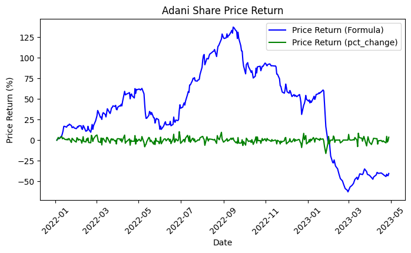

```python
# Set the figure size
plt.figure(figsize=(8, 4))

# Set the index of the DataFrame as the 'Date' column
#adani_df.set_index('Date', inplace=True)

# Plot price return using formula
price_return_formula = ((adani_df['Close'] - adani_df['Close'].iloc[0]) / adani_df['Close'].iloc[0]) * 100
plt.plot(adani_df.index, price_return_formula, label='Price Return (Formula)', color='blue')

# Plot price return using pct_change()
price_tot_return = ((adani_df['Close'] - adani_df['Open'] )/ adani_df['Open'])*100
plt.plot(adani_df.index, price_tot_return, label='Price Return (pct_change)', color='green')

# Set the labels and title
plt.xlabel('Date')
plt.ylabel('Price Return (%)')
plt.title('Adani Share Price Return')

# Rotate x-axis labels for better readability
plt.xticks(rotation=45)

# Display the legend
plt.legend()

# Show the plot
plt.show()
```

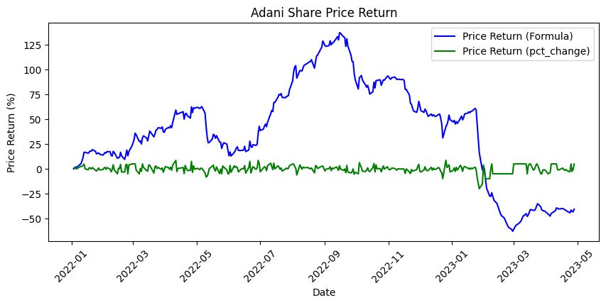

```python
# Set the figure size
plt.figure(figsize=(10,4))

# Set the index of the DataFrame as the 'Date' column
#adani_df.set_index('Date', inplace=True)

# Plot price return using formula
price_return_formula = ((adani_df['Close'] - adani_df['Close'].iloc[0]) / adani_df['Close'].iloc[0]) * 100
plt.plot(adani_df.index, price_return_formula, label='Price Return (Formula)', color='blue')

# Plot price return using pct_change()
price_return_pct_change = adani_df['Close'].pct_change() * 100
plt.plot(adani_df.index, price_return_pct_change, label='Price Return (pct_change)', color='green')

# Set the labels and title
plt.xlabel('Date')
plt.ylabel('Price Return (%)')
plt.title('Adani Share Price Return')

# Rotate x-axis labels for better readability
plt.xticks(rotation=45)

# Display the legend
plt.legend()

# Show the plot
plt.show()
```

```python
adani_df.head()
```

| Date | Open | High | Low | Close | Adj Close | Volume | Daily Change | % Daily Change |
| --- | --- | --- | --- | --- | --- | --- | --- | --- |
| 2022-01-03 | 1735.000000 | 1755.0 | 1710.000000 | 1731.099976 | 1731.099976 | 32602 | NaN | NaN |
| 2022-01-04 | 1731.099976 | 1775.0 | 1700.000000 | 1754.949951 | 1754.949951 | 42498 | 23.849976 | 1.377735 |
| 2022-01-05 | 1706.099976 | 1780.5 | 1706.099976 | 1761.050049 | 1761.050049 | 54105 | 6.100098 | 0.347594 |
| 2022-01-06 | 1730.000000 | 1770.0 | 1710.000000 | 1760.050049 | 1760.050049 | 51023 | -1.000000 | -0.056784 |
| 2022-01-07 | 1740.099976 | 1780.0 | 1721.849976 | 1776.000000 | 1776.000000 | 64894 | 15.949951 | 0.906221 |

```python
# Adding Total Return and Price return to the adani_df

# Create a new dataframe with selected columns
adani_df1 = adani_df[['Open', 'High', 'Low', 'Close', 'Adj Close', 'Volume']].copy()

# Calculate and add the Total Return column
adani_df1['Total Return'] = ((adani_df['Close'] - adani_df['Open']) / adani_df['Open']) * 100

# Calculate and add the Price Return column
adani_df1['Price Return'] = ((adani_df['Close'] - adani_df['Close'].iloc[0]) / adani_df['Close'].iloc[0]) * 100

adani_df1.head()
```

| Date | Open | High | Low | Close | Adj Close | Volume | Total Return | Price Return |
| --- | --- | --- | --- | --- | --- | --- | --- | --- |
| 2022-01-03 | 1735.000000 | 1755.0 | 1710.000000 | 1731.099976 | 1731.099976 | 32602 | -0.224785 | 0.000000 |
| 2022-01-04 | 1731.099976 | 1775.0 | 1700.000000 | 1754.949951 | 1754.949951 | 42498 | 1.377735 | 1.377735 |
| 2022-01-05 | 1706.099976 | 1780.5 | 1706.099976 | 1761.050049 | 1761.050049 | 54105 | 3.220800 | 1.730118 |
| 2022-01-06 | 1730.000000 | 1770.0 | 1710.000000 | 1760.050049 | 1760.050049 | 51023 | 1.736997 | 1.672351 |
| 2022-01-07 | 1740.099976 | 1780.0 | 1721.849976 | 1776.000000 | 1776.000000 | 64894 | 2.063101 | 2.593728 |

```python
adani_df1.tail()
```

| Date | Open | High | Low | Close | Adj Close | Volume | Total Return | Price Return |
| --- | --- | --- | --- | --- | --- | --- | --- | --- |
| 2023-04-24 | 998.950012 | 999.000000 | 960.400024 | 965.099976 | 965.099976 | 290276 | -3.388562 | -44.249322 |
| 2023-04-25 | 969.000000 | 1013.349976 | 965.200012 | 1012.950012 | 1012.950012 | 742228 | 4.535605 | -41.485181 |
| 2023-04-26 | 1012.000000 | 1021.200012 | 985.000000 | 987.799988 | 987.799988 | 528831 | -2.391306 | -42.938016 |
| 2023-04-27 | 989.849976 | 997.700012 | 975.049988 | 982.299988 | 982.299988 | 236845 | -0.762741 | -43.255733 |
| 2023-04-28 | 995.000000 | 1031.400024 | 987.099976 | 1029.449951 | 1029.449951 | 914154 | 3.462307 | -40.532034 |

## 4. Voltality of the market

- Market volatility refers to the degree of price variability or fluctuations in the overall financial market.
- It represents the rate at which market prices change over a given period, indicating the level of uncertainty and risk in the market.
- The most widely used measure of market volatility is the calculation of the standard deviation of the index returns.
- The formula for calculating volatility is as follows:

  $\boxed{\text{Volatility} = \sqrt{\frac{\sum{(R_i - R_{\rm avg})^2}}{(n-1)}} = \sqrt{\text{Variance}}}$

  Where:
  - $R_i$ is the return for a given day or time period
  - $R_{\rm avg}$ is the average return over the same period
  - $n$ is the number of days or time periods being analyzed
- Variance is the average of the squared differences between each day's return and the average return over the same period.
- Volatility is a measure of the degree of variation or dispersion in the price of a financial instrument, typically represented as a percentage. It quantifies the magnitude of price fluctuations and reflects the level of risk associated with an investment.
- The formula can also be simplified as follows:

  $\boxed{\text{Volatility} = \sqrt{\text{Variance}} = \sqrt{252} \times \text{Standard deviation}}$

  Where:
  - $\sqrt{252}$ is the square root of the number of trading days in a year (typically used for daily price data)
  - Standard Deviation is the measure of dispersion calculated from the logarithmic returns of the financial instrument over the specified period.
  - This formula is often applied to historical price data to estimate the volatility of a financial instrument. It provides a standardized measure of the instrument's price fluctuations, allowing investors to compare the volatility of different assets and make informed investment decisions.
- **Application:**

  Volatility is a measure of the degree of variation or dispersion in the price or returns of a financial instrument. A higher volatility indicates larger price swings, while lower volatility suggests relatively stable prices.

  Based on the volatility index, here are a few things that can be inferred or predicted:
  - **Market Risk:** Higher volatility generally implies higher market risk. It suggests that prices can fluctuate significantly in a short period, indicating a higher level of uncertainty and potential for larger losses or gains.
  - **Trading Opportunities:** Volatility can present trading opportunities for investors and traders. Higher volatility can create more significant price movements, providing potential opportunities for profit through well-timed trades or strategies.
  - **Option Pricing:** Volatility is a crucial factor in determining option prices. Higher volatility leads to higher option premiums since there is an increased likelihood of larger price swings and potential profits for option holders.
  - **Investor Sentiment:** Volatility can reflect investor sentiment and market conditions. During periods of high volatility, it often indicates increased fear, uncertainty, or market turbulence. Conversely, low volatility may suggest a more stable and confident market environment.
  - **Risk Management:** Volatility measures can be used for risk management purposes. Investors and portfolio managers may adjust their strategies, asset allocations, or position sizes based on the level of volatility to manage their exposure to market risk.

  It is important to note that volatility alone cannot provide a complete assessment of market risk. Other factors such as economic conditions, geopolitical events, and market fundamentals should also be considered in determining the overall risk level.

```python
# Create a new dataframe with selected columns
adani_df2 = adani_df[['Open', 'High', 'Low', 'Close', 'Adj Close', 'Volume']].copy()

# Calculate the daily returns
returns = adani_df2['Close'].pct_change()

# Calculate the average return
average_return = returns.mean()

# Calculate the squared differences from the average return
squared_diff = (returns - average_return)**2

# Calculate the sum of squared differences
sum_squared_diff = squared_diff.sum()

# Calculate the volatility (square root of the average squared differences)
volatility = np.sqrt(sum_squared_diff / len(returns))

print("Volatility:", volatility)
```

```
Volatility: 0.03596809240505215
```

```python
# Calculate the logarithmic returns
log_returns = np.log(adani_df2['Close'] / adani_df2['Close'].shift(1))

# Calculate the volatility (standard deviation of log returns)
volatility = log_returns.std()

print("Volatility:", volatility)
```

```
Volatility: 0.036798934501245766
```

```python
# Assuming your DataFrame for last one month
start_date = pd.to_datetime('2023-03-28')
end_date = pd.to_datetime('2023-04-28')

last_one_month_data = adani_df1.loc[start_date:end_date]

returns = last_one_month_data['Close'].pct_change()
volatility1 = returns.std()
volatility1
```

```
0.03226102776885272
```

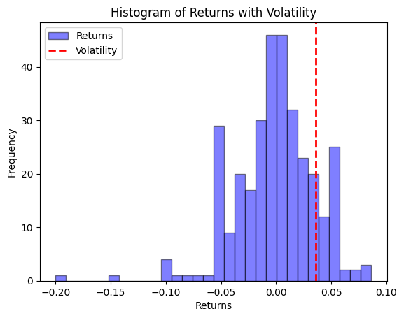

```python
# Calculate the returns
returns = adani_df['Close'].pct_change()

# Calculate the volatility
volatility = returns.std()

# Plot the histogram of returns
plt.hist(returns, bins=30, alpha=0.5, color='blue', edgecolor='black', label='Returns')

# Add a vertical line to indicate the volatility
plt.axvline(x=volatility, color='red', linestyle='--', linewidth=2, label='Volatility')

# Set plot labels and title
plt.xlabel('Returns')
plt.ylabel('Frequency')
plt.title('Histogram of Returns with Volatility')

# Add legend
plt.legend()

# Show the plot
plt.show()
```

## 5. Normalization

- Normalization of data in a DataFrame is the process of scaling the values to a specific range or distribution.
- It is commonly done to bring all the variables to a similar scale and remove any bias or distortion caused by differences in the magnitude of values.
- The use of normalization in a DataFrame has several benefits:
  - **Improved Comparability:** By scaling the variables to a common range, normalization allows for a fairer and more meaningful comparison between different variables. It ensures that no single variable dominates the analysis simply due to its larger values.
  - **Elimination of Skewness:** Normalization helps in removing the skewness or imbalance in the distribution of data. It makes the data distribution more symmetrical and reduces the impact of outliers.
  - **Effective Model Training:** Many machine learning algorithms, such as gradient descent-based methods, perform better when the input features are on a similar scale. Normalizing the data can help in improving the convergence of these algorithms and prevent any one variable from dominating the model training process.
  - **Interpretability:** Normalization makes it easier to interpret the impact or importance of each variable. When variables are on the same scale, it becomes simpler to compare their coefficients or weights in a model and understand their relative influence.
  - **Data Visualization:** Normalized data can enhance data visualization by preventing one variable from overshadowing others due to its larger magnitude. It allows for a more accurate representation of the relationships and patterns among variables.
- The mathematical formula used for Min-Max normalization is:

  $\boxed{X_{\rm scaled} = \frac{X - X_{\rm min}}{X_{\rm max} - X_{\rm min}}}$

  where:
  - $X$ is the original value of a data point.
  - $X_{\rm scaled}$ is the normalized value of the data point.
  - $X_{\rm min}$ is the minimum value of the variable being normalized.
  - $X_{\rm max}$ is the maximum value of the variable being normalized.

  This formula scales the values of a variable to the range $[0, 1]$. The minimum value $X_{\rm min}$ is transformed to $0$, the maximum value $X_{\rm max}$ is transformed to $1$, and all other values are scaled proportionally in between.

```python
from sklearn.preprocessing import MinMaxScaler

# Droping previosuly created columns 'Daily Change' and '% Daily Change' columns from adani_df
adani_df_dropped = adani_df.drop(['Daily Change', '% Daily Change'], axis=1)

# Make a copy of the original DataFrame
adani_df_dropped_copy = adani_df_dropped.copy()

# Create a copy of the DataFrame to preserve the original data
adani_df_normalized = adani_df_dropped_copy.copy()

# Select the columns to normalize
columns_to_normalize = ['Open', 'High', 'Low', 'Close', 'Volume']

# Initialize the MinMaxScaler
scaler = MinMaxScaler()

# Normalize the selected columns
adani_df_normalized[columns_to_normalize] = scaler.fit_transform(adani_df_dropped_copy[columns_to_normalize])

'''
fit_transform() method to perform the Min-Max scaling on the selected columns of adani_df.
The fit_transform() method scales the values in each column to the range [0, 1].
'''
```

```
' \nfit_transform() method to perform the Min-Max scaling on the selected columns of adani_df. \nThe fit_transform() method scales the values in each column to the range [0, 1].\n'
```

```python
# Display the normalized DataFrame
adani_df_normalized.head()
```

| Date | Open | High | Low | Close | Adj Close | Volume |
| --- | --- | --- | --- | --- | --- | --- |
| 2022-01-03 | 0.312297 | 0.303339 | 0.321020 | 0.314282 | 1731.099976 | 0.000331 |
| 2022-01-04 | 0.311193 | 0.308953 | 0.318044 | 0.321170 | 1754.949951 | 0.002243 |
| 2022-01-05 | 0.304118 | 0.310497 | 0.319859 | 0.322931 | 1761.050049 | 0.004485 |
| 2022-01-06 | 0.310882 | 0.307550 | 0.321020 | 0.322643 | 1760.050049 | 0.003890 |
| 2022-01-07 | 0.313740 | 0.310357 | 0.324548 | 0.327249 | 1776.000000 | 0.006569 |

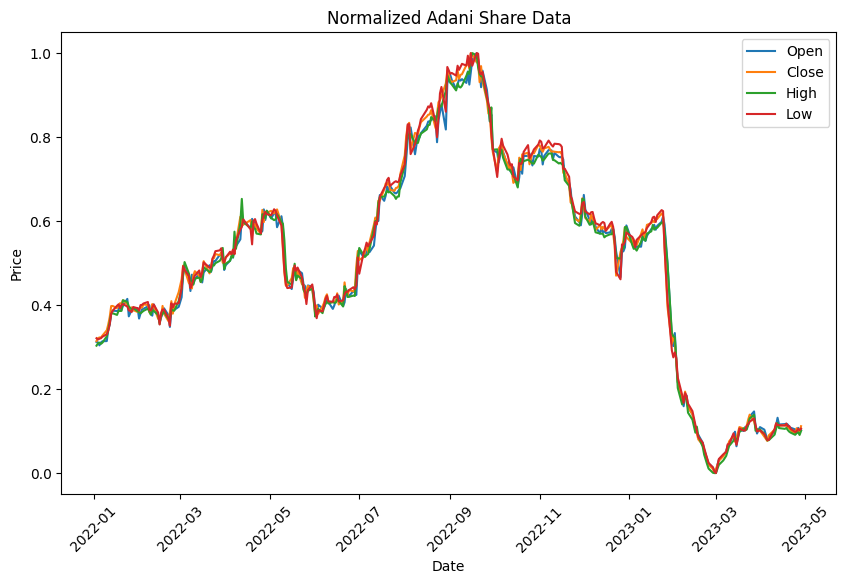

```python
# If date is not datetime format then Convert the 'Date' column to datetime type using
# adani_df['Date'] = pd.to_datetime(adani_df['Date'])

# Set the figure size
plt.figure(figsize=(10, 6))
# Plot 'Open' price
sns.lineplot(x='Date', y='Open', data=adani_df_normalized, label='Open')

# Plot 'Close' price
sns.lineplot(x='Date', y='Close', data=adani_df_normalized, label='Close')

# Plot 'High' price
sns.lineplot(x='Date', y='High', data=adani_df_normalized, label='High')

# Plot 'Low' price
sns.lineplot(x='Date', y='Low', data=adani_df_normalized, label='Low')

# Set the labels and title
plt.xlabel('Date')
plt.ylabel('Price')
plt.title('Normalized Adani Share Data')

# Rotate x-axis labels for better readability
plt.xticks(rotation=45)

# Display the legend
plt.legend()

# Show the plot
plt.show()
```

```python
adani_df_normalized.head()
```

| Date | Open | High | Low | Close | Adj Close | Volume |
| --- | --- | --- | --- | --- | --- | --- |
| 2022-01-03 | 0.312297 | 0.303339 | 0.321020 | 0.314282 | 1731.099976 | 0.000331 |
| 2022-01-04 | 0.311193 | 0.308953 | 0.318044 | 0.321170 | 1754.949951 | 0.002243 |
| 2022-01-05 | 0.304118 | 0.310497 | 0.319859 | 0.322931 | 1761.050049 | 0.004485 |
| 2022-01-06 | 0.310882 | 0.307550 | 0.321020 | 0.322643 | 1760.050049 | 0.003890 |
| 2022-01-07 | 0.313740 | 0.310357 | 0.324548 | 0.327249 | 1776.000000 | 0.006569 |

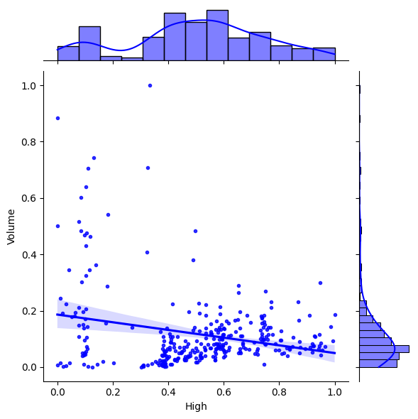

```python
# Scatter Plot with Marginal Histograms along with linear regression
sns.jointplot(data=adani_df_normalized.loc['2020-01-01':], x='High', y='Volume', kind="reg", color='blue', marker=".")
```